# Dissertation Analysis: Demographics and Strategy

Jamiahus Walton

2019-06-17

# Motivation

The motivation behind this analyis is to explore behavior (e.g., distance traveled) and characteristics (e.g., demographics or strategies). I want to explore the survey data and see if any of it can help explain the variance in the data.

# Q: Are there similar demographic characterisitcs for teams that use a certain strategy

## Individual

**Note:** 1 = Strongly Agree, 7 = Strgonly Disagree

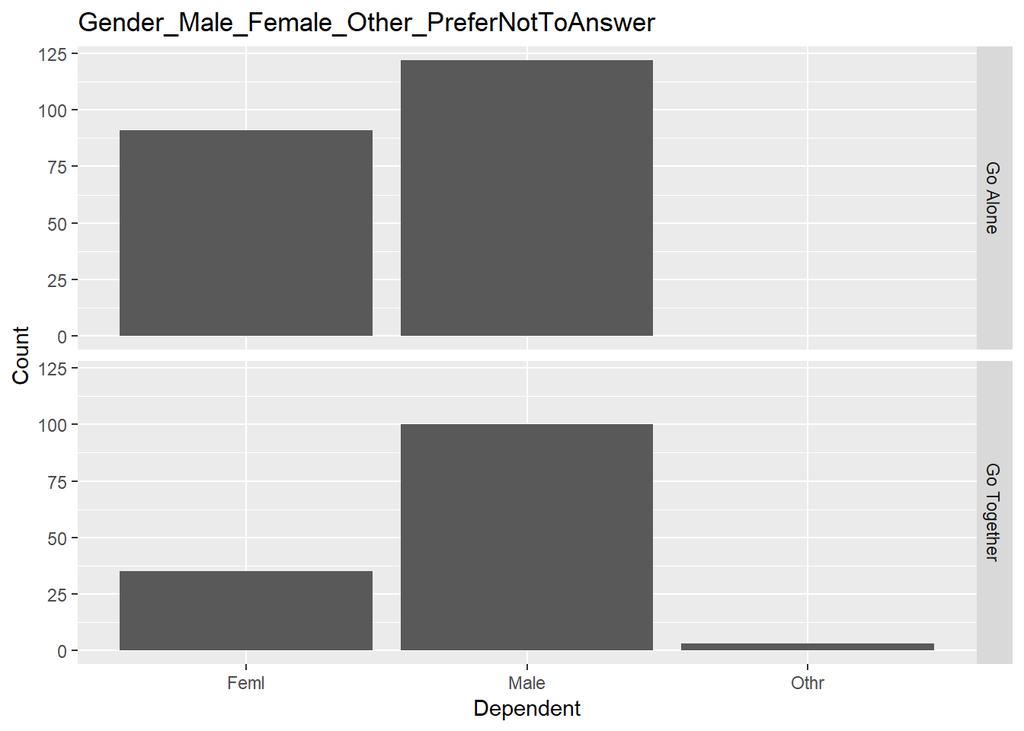

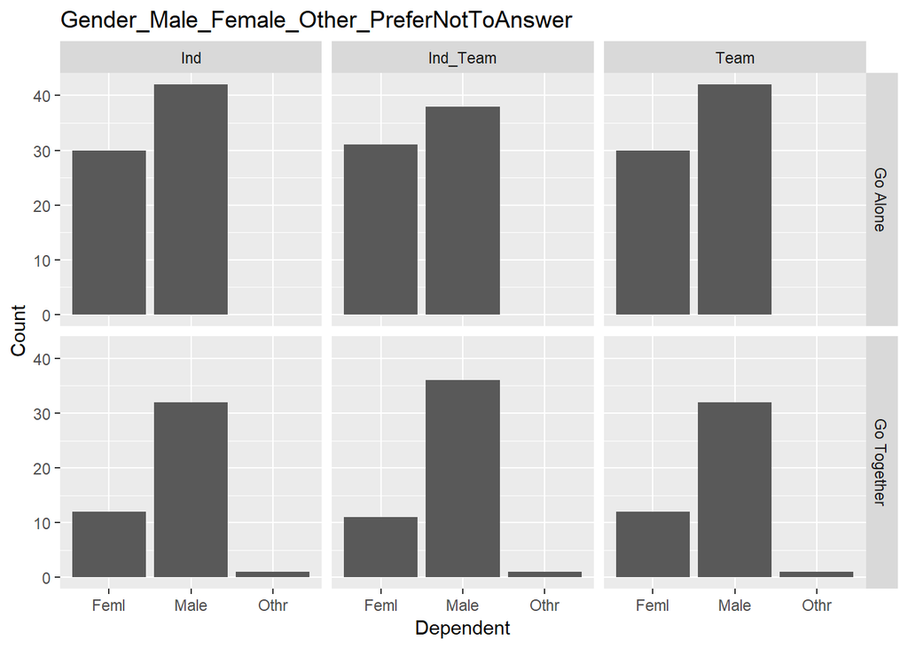

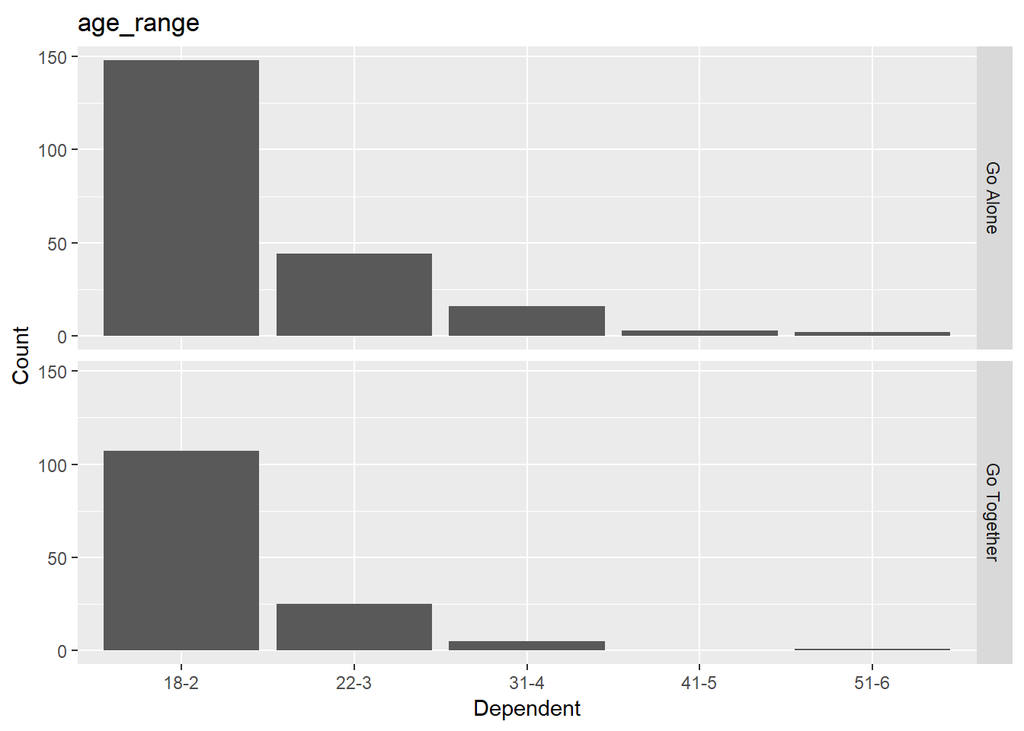

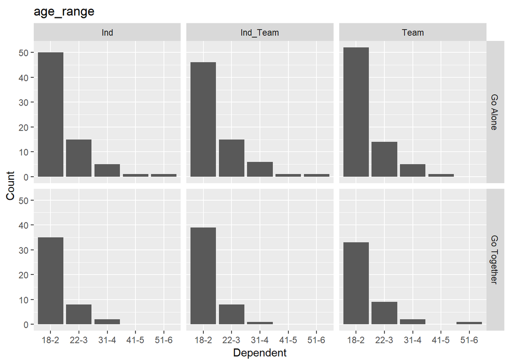

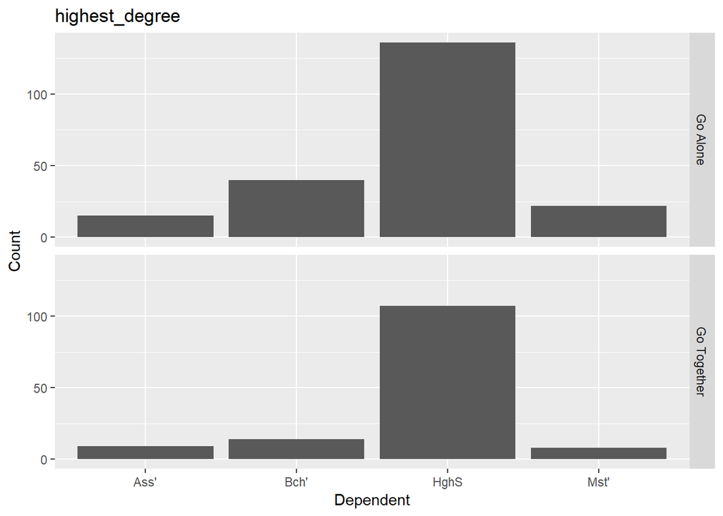

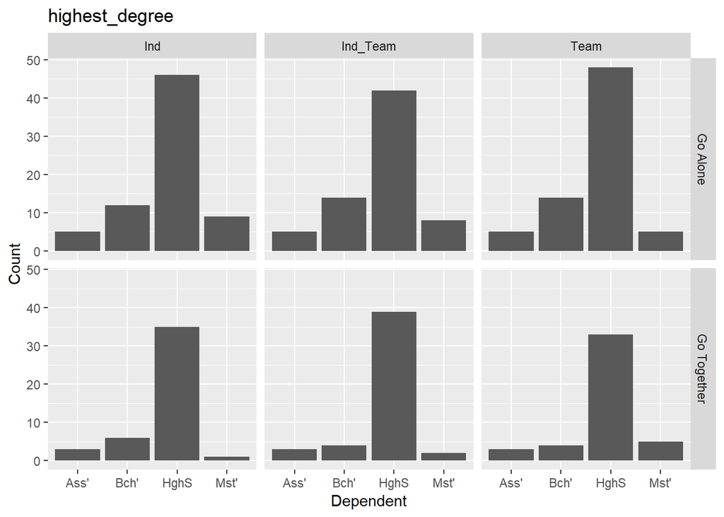

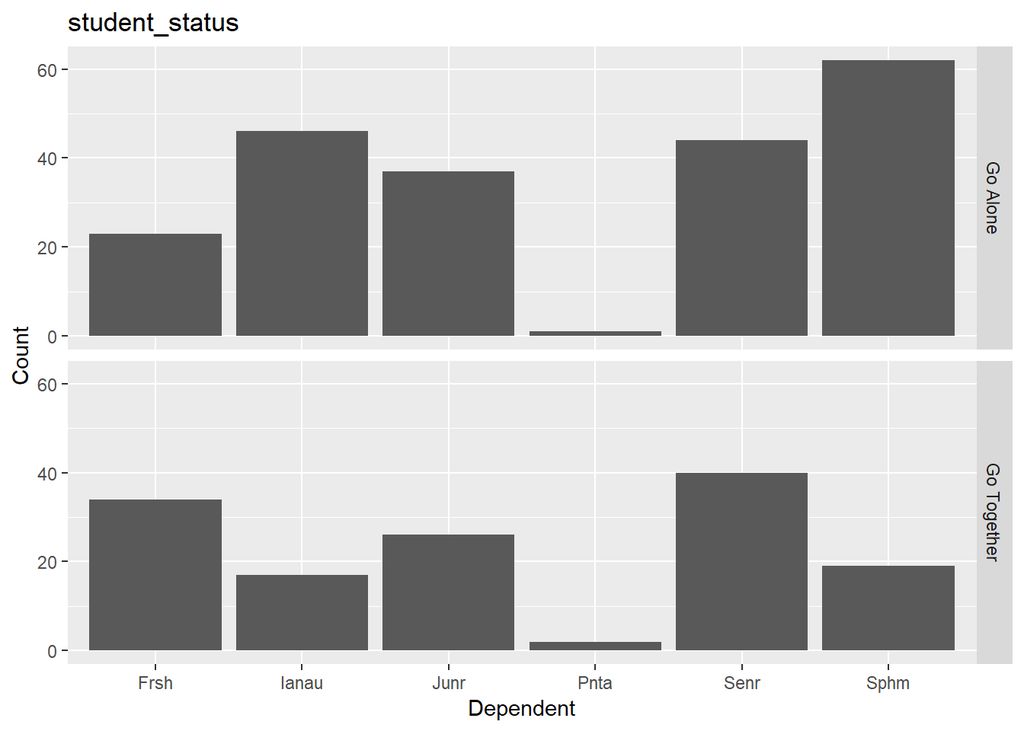

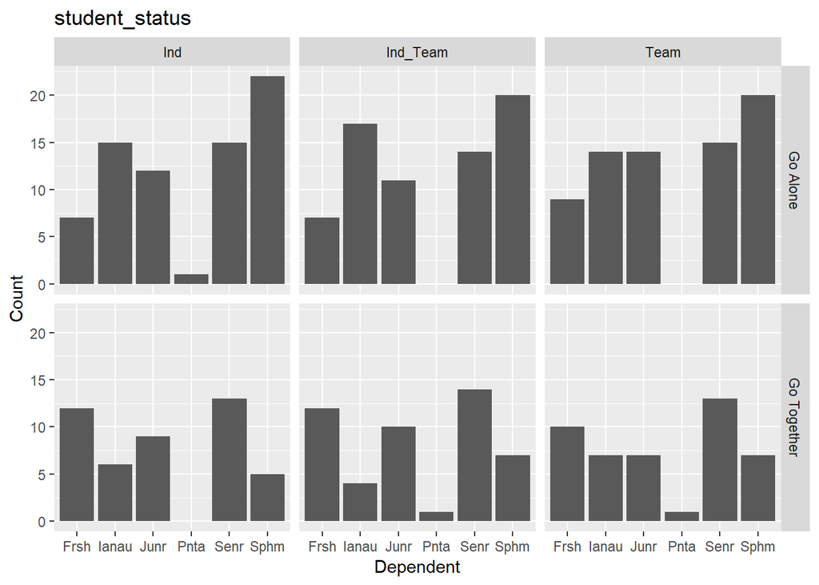

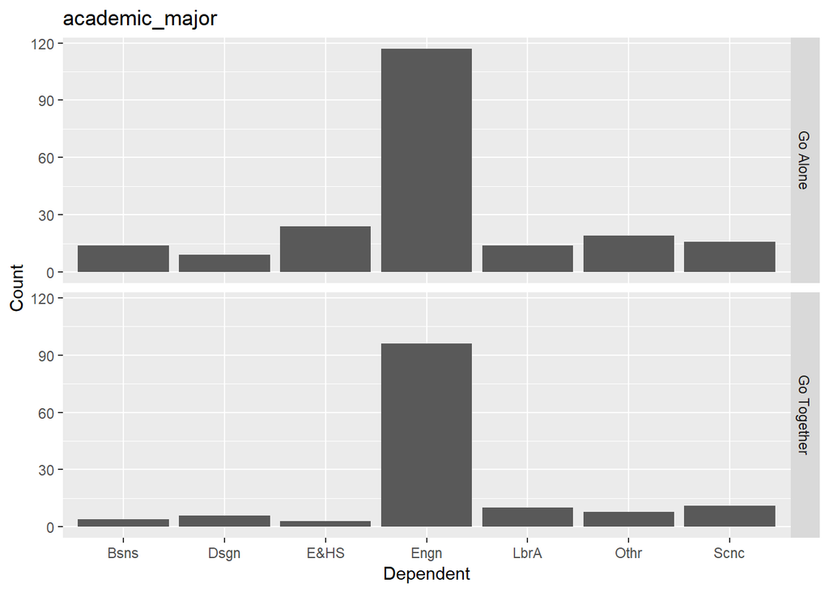

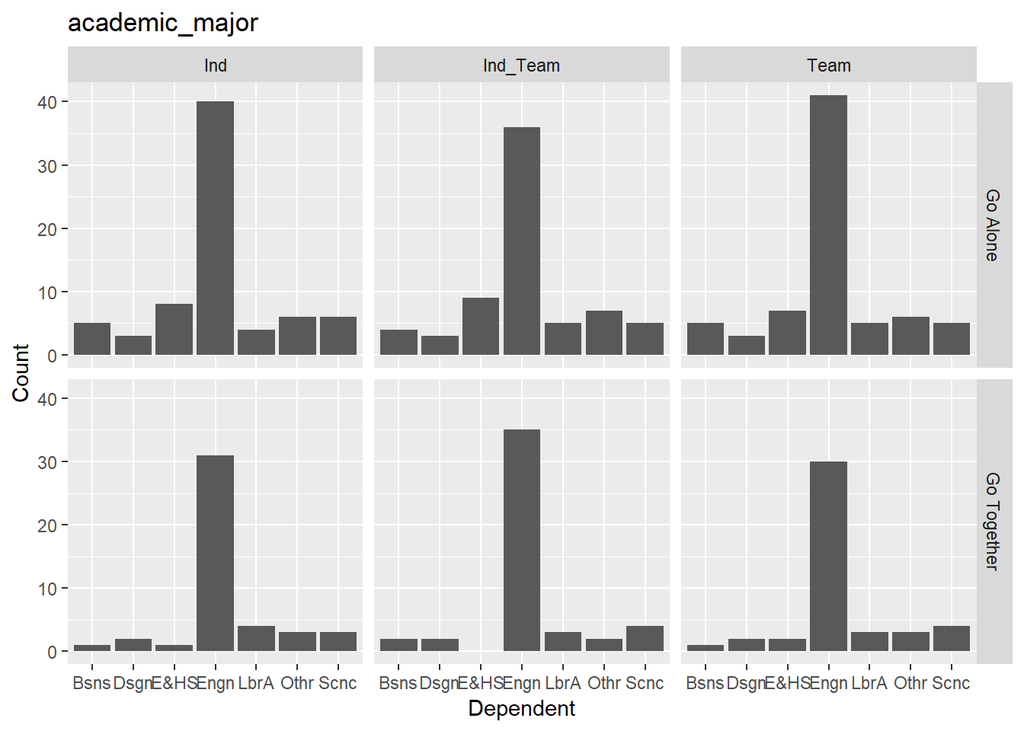

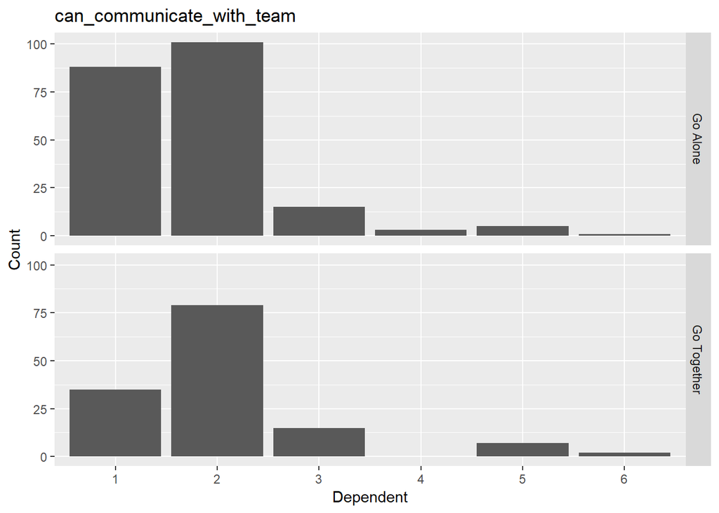

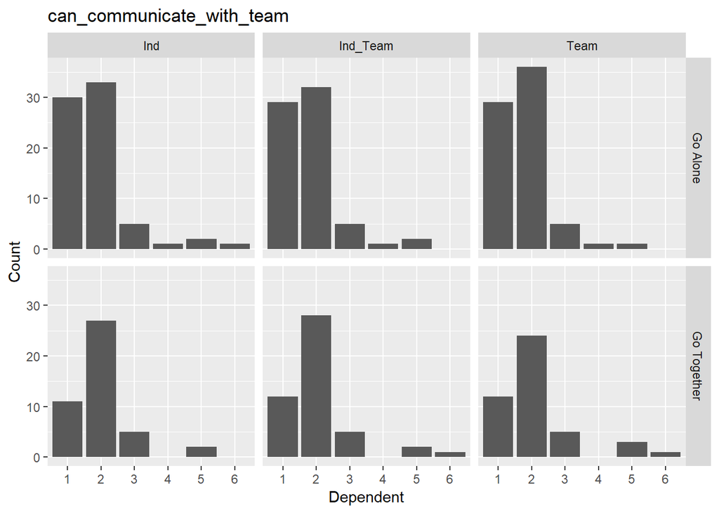

[16 more figures not shown]

```r
demo_names <- c("Gender_Male_Female_Other_PreferNotToAnswer",
                "age_range",
                "highest_degree",
                "student_status",
                "academic_major",
                "can_communicate_with_team",
                "can_hold_my_team_back",
                "can_team_slow_me_down",
                "can_teams_perform_better_than_ind",
                "can_feedback_useful_for_teamwork",
                "can_i_learn_better_in_team",
                "can_navigate_VE",
                "video_game_play_frequency",
                "work_in_team_frequency")

for (name in demo_names) {
  dependent<- name

  y_label_ind <- "Count"

  plot_data_ind <- ind_data %>%
    select(.data[[dependent]], Dominate.Strategy, Target, IndividualScore)

  print(
    suppressWarnings( # This warning supressing is needed for because there is a bug that prevents an HTML document to be generated.
      ggplot(data = plot_data_ind) +
      geom_histogram(aes(x = .data[[dependent]]), stat = "count") +
      facet_grid(Dominate.Strategy ~ .) +
      labs(title = dependent, x = "Dependent", y = y_label_ind) +
      scale_x_discrete(labels = abbreviate)
    )
  )

  print(
    suppressWarnings( # This warning supressing is needed for because there is a bug that prevents an HTML document to be generated.
      ggplot(data = plot_data_ind) +
      geom_histogram(aes(x = .data[[dependent]]), stat = "count") +
      facet_grid(Dominate.Strategy ~ Target) +
      labs(title = dependent, x = "Dependent", y = y_label_ind) +
      scale_x_discrete(labels = abbreviate)
    )
  )
}
```

Overall, I do not see any obvious characterisitcs that show a partern for teams using the differnet strategies.

There is possible patter for the dependent variable **“can_team_slow_me_down”**. The questions asked was the statement was “Team members slow me down”. The participants selected a value from a range of “Strongly Agree (1)” to Strongly Disagree (7). It looks like the center of the distribution of answers for teams that used the Go Alone strategy is around 5 (neither agree nor disagree).

# Q: Are there interesting distributions for self-reported cognitive workload?

## Individual

### Graph for all TLX metrics

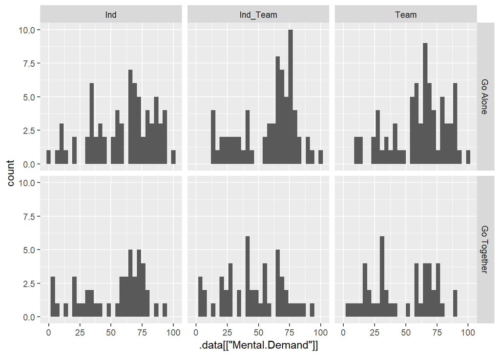

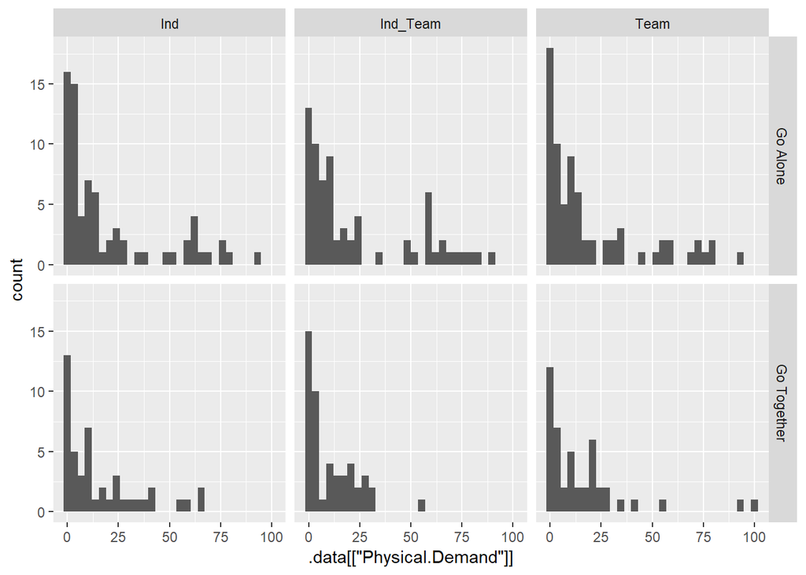

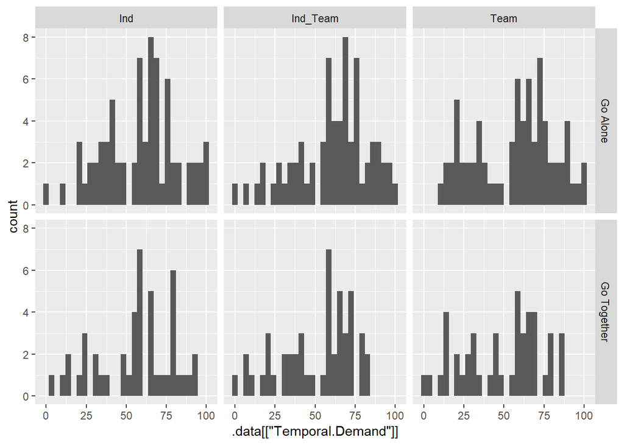

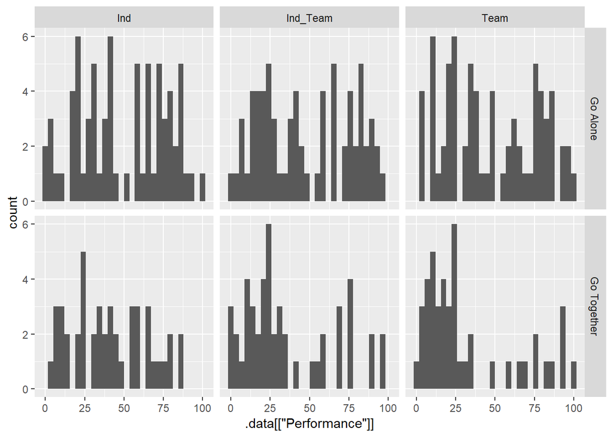

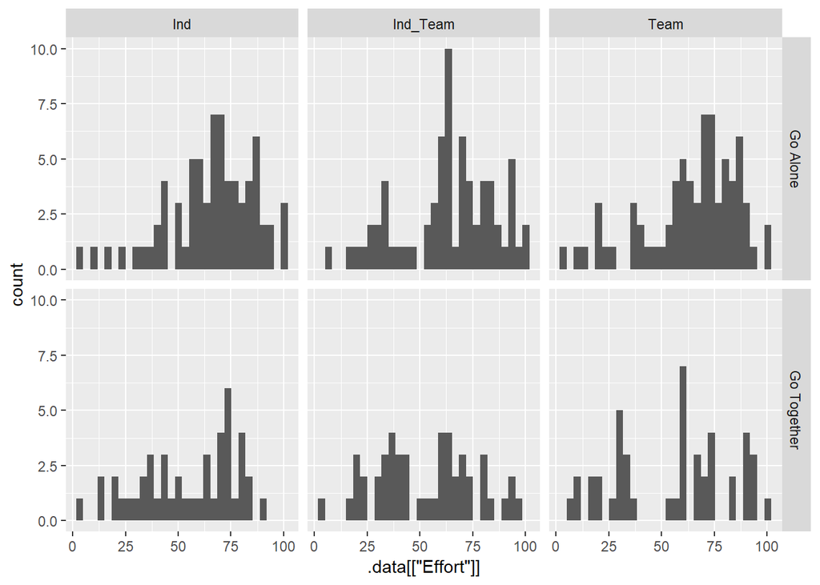

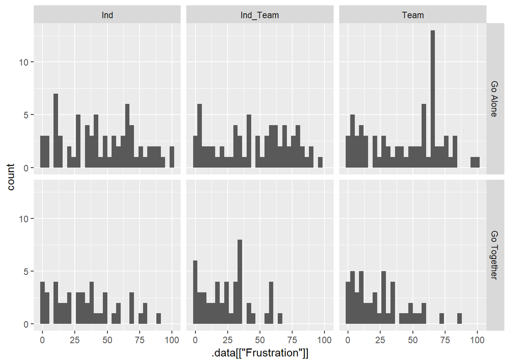

```r
TLX_Scale_Names <- c("Mental.Demand", "Physical.Demand", "Temporal.Demand", "Performance", "Effort", "Frustration" )
dependent<- "Temporal.Demand"

for (name in TLX_Scale_Names) {
  dependent<- name

  y_label_ind <- "Count"

  plot_data_ind <- ind_data %>%
  select(TLX_Scale_Names,
         Dominate.Strategy,
         Target,
         SessionOrder)
  plot<- ggplot(data = plot_data_ind) +
    geom_histogram(aes(x = .data[[dependent]]), bins = 30) +
    facet_grid(Dominate.Strategy ~ Target)

  print(
    plot
  )
}
```

It looks like there may be a patter in the following workload channels: *Performance, Frustraton, and Effort*.

I want to fit a model on the data split by strategy. I want to see if a model with no interaction (i.e., only using the session order and target variable) can explain the varience.

### Performance

#### Go Alone

```r
dependent<- "Performance"

plot_data_ind <- ind_data %>%
  select(dependent,
         Dominate.Strategy,
         Target,
         SessionOrder,
         Team,
         Player_ID)

plot_data_GA <-plot_data_ind %>% filter(Dominate.Strategy == "Go Alone")

model.NoInteraction<- model_data_Target_Session(df = plot_data_GA, dependent =  dependent, model.type =  "NoInteraction", is.team = FALSE, is.robust = FALSE)
emmeans(model.NoInteraction, list(pairwise ~ Target),adjust = "tukey")
```

```
## $`emmeans of Target`
##  Target   emmean   SE   df lower.CL upper.CL
##  Ind        48.7 3.37 47.1     41.9     55.5
##  Ind_Team   47.0 3.44 49.1     40.1     53.9
##  Team       47.8 3.37 47.1     41.0     54.6
##
## Results are averaged over the levels of: SessionOrder
## Degrees-of-freedom method: kenward-roger
## Results are given on the (.| (not the response) scale.
## Confidence level used: 0.95
##
## $`pairwise differences of Target`
##  contrast        estimate   SE  df t.ratio p.value
##  Ind - Ind_Team     1.749 3.13 134  0.558  0.8426
##  Ind - Team         0.902 3.14 137  0.288  0.9554
##  Ind_Team - Team   -0.847 3.12 133 -0.271  0.9602
##
## Results are averaged over the levels of: SessionOrder
## P value adjustment: tukey method for comparing a family of 3 estimates
```

Statistically, it looks like there is no significant difference between the Target levels in self performance rating for teams that used Go Alone.

#### Go Together

```r
dependent<- "Performance"

plot_data_ind <- ind_data %>%
  select(dependent,
         Dominate.Strategy,
         Target,
         SessionOrder,
         Team,
         Player_ID)

plot_data_GA <-plot_data_ind %>% filter(Dominate.Strategy == "Go Together")

model.NoInteraction<- model_data_Target_Session(df = plot_data_GA, dependent =  dependent, model.type =  "NoInteraction", is.team = FALSE, is.robust = FALSE)
```

```
## Warning in checkConv(attr(opt, "derivs"), opt$par, ctrl =
## control$checkConv, : Model failed to converge with max|grad| = 0.00205217
## (tol = 0.002, component 1)
```

```r
emmeans(model.NoInteraction, list(pairwise ~ Target),adjust = "tukey")
```

```
## $`emmeans of Target`
##  Target   emmean   SE   df lower.CL upper.CL
##  Ind        42.0 4.24 26.4     33.3     50.7
##  Ind_Team   38.8 4.20 25.6     30.1     47.4
##  Team       34.5 4.25 26.6     25.8     43.3
##
## Results are averaged over the levels of: SessionOrder
## Degrees-of-freedom method: kenward-roger
## Results are given on the (.| (not the response) scale.
## Confidence level used: 0.95
##
## $`pairwise differences of Target`
##  contrast        estimate   SE   df t.ratio p.value
##  Ind - Ind_Team      3.23 3.30 82.6 0.977   0.5937
##  Ind - Team          7.47 3.45 85.7 2.162   0.0836
##  Ind_Team - Team     4.24 3.24 82.3 1.308   0.3948
##
## Results are averaged over the levels of: SessionOrder
## P value adjustment: tukey method for comparing a family of 3 estimates
```

There is no statisitcally significant difference between the conditions. HOwever, it is important to note that there is a **margnially significant result** between Team and Ind condtions. The difference indicates that participants felt they did better in the Team condition when compared to the Ind condition.

**Warning/Note**: The model failed to converge

### Frustraton

#### Go Alone

```r
dependent<- "Frustration"

plot_data_ind <- ind_data %>%
  select(dependent,
         Dominate.Strategy,
         Target,
         SessionOrder,
         Team,
         Player_ID)

plot_data_GA <-plot_data_ind %>% filter(Dominate.Strategy == "Go Alone")

model.NoInteraction<- model_data_Target_Session(df = plot_data_GA, dependent =  dependent, model.type =  "NoInteraction", is.team = FALSE, is.robust = FALSE)
emmeans(model.NoInteraction, list(pairwise ~ Target),adjust = "tukey")
```

```
## $`emmeans of Target`
##  Target   emmean   SE   df lower.CL upper.CL
##  Ind        44.8 3.43 48.1     37.9     51.7
##  Ind_Team   44.0 3.50 50.1     37.0     51.1
##  Team       43.8 3.43 48.1     36.9     50.7
##
## Results are averaged over the levels of: SessionOrder
## Degrees-of-freedom method: kenward-roger
## Results are given on the (.| (not the response) scale.
## Confidence level used: 0.95
##
## $`pairwise differences of Target`
##  contrast        estimate   SE  df t.ratio p.value
##  Ind - Ind_Team     0.767 3.24 134 0.237   0.9696
##  Ind - Team         0.968 3.24 137 0.299   0.9519
##  Ind_Team - Team    0.202 3.22 134 0.063   0.9978
##
## Results are averaged over the levels of: SessionOrder
## P value adjustment: tukey method for comparing a family of 3 estimates
```

No statisitcally significant difference among the conditions

#### Go Together

```r
dependent<- "Frustration"

plot_data_ind <- ind_data %>%
  select(dependent,
         Dominate.Strategy,
         Target,
         SessionOrder,
         Team,
         Player_ID)

plot_data_GA <-plot_data_ind %>% filter(Dominate.Strategy == "Go Together")

model.NoInteraction<- model_data_Target_Session(df = plot_data_GA, dependent =  dependent, model.type =  "NoInteraction", is.team = FALSE, is.robust = FALSE)
emmeans(model.NoInteraction, list(pairwise ~ Target),adjust = "tukey")
```

```
## $`emmeans of Target`
##  Target   emmean   SE   df lower.CL upper.CL
##  Ind        36.3 3.55 29.6     29.0     43.6
##  Ind_Team   27.6 3.51 28.6     20.4     34.8
##  Team       25.3 3.57 29.7     18.0     32.5
##
## Results are averaged over the levels of: SessionOrder
## Degrees-of-freedom method: kenward-roger
## Results are given on the (.| (not the response) scale.
## Confidence level used: 0.95
##
## $`pairwise differences of Target`
##  contrast        estimate   SE   df t.ratio p.value
##  Ind - Ind_Team      8.72 3.09 83.3 2.819   0.0164
##  Ind - Team         11.03 3.22 87.1 3.421   0.0027
##  Ind_Team - Team     2.31 3.03 83.1 0.760   0.7282
##
## Results are averaged over the levels of: SessionOrder
## P value adjustment: tukey method for comparing a family of 3 estimates
```

There is a **significant different** between Ind and Team, and Ind and Ind_Team conditons. The difference indictate frustation is higher in the Ind condition when compared to the Team or the Ind_Team condition.

### Effort

#### Go Alone

```r
dependent<- "Effort"

plot_data_ind <- ind_data %>%
  select(dependent,
         Dominate.Strategy,
         Target,
         SessionOrder,
         Team,
         Player_ID)

plot_data_GA <-plot_data_ind %>% filter(Dominate.Strategy == "Go Alone")

model.NoInteraction<- model_data_Target_Session(df = plot_data_GA, dependent =  dependent, model.type =  "NoInteraction", is.team = FALSE, is.robust = FALSE)
emmeans(model.NoInteraction, list(pairwise ~ Target),adjust = "tukey")
```

```
## $`emmeans of Target`
##  Target   emmean   SE   df lower.CL upper.CL
##  Ind        65.0 2.86 37.3     59.2     70.8
##  Ind_Team   62.7 2.90 38.8     56.8     68.6
##  Team       64.2 2.86 37.3     58.4     70.0
##
## Results are averaged over the levels of: SessionOrder
## Degrees-of-freedom method: kenward-roger
## Results are given on the (.| (not the response) scale.
## Confidence level used: 0.95
##
## $`pairwise differences of Target`
##  contrast        estimate   SE  df t.ratio p.value
##  Ind - Ind_Team     2.285 2.10 132  1.087  0.5238
##  Ind - Team         0.816 2.11 134  0.387  0.9209
##  Ind_Team - Team   -1.469 2.09 132 -0.702  0.7628
##
## Results are averaged over the levels of: SessionOrder
## P value adjustment: tukey method for comparing a family of 3 estimates
```

No statistical differences.

#### Go Together

```r
dependent<- "Effort"

plot_data_ind <- ind_data %>%
  select(dependent,
         Dominate.Strategy,
         Target,
         SessionOrder,
         Team,
         Player_ID)

plot_data_GA <-plot_data_ind %>% filter(Dominate.Strategy == "Go Together")

model.NoInteraction<- model_data_Target_Session(df = plot_data_GA, dependent =  dependent, model.type =  "NoInteraction", is.team = FALSE, is.robust = FALSE)
emmeans(model.NoInteraction, list(pairwise ~ Target),adjust = "tukey")
```

```
## $`emmeans of Target`
##  Target   emmean   SE   df lower.CL upper.CL
##  Ind        56.2 3.50 30.4     49.1     63.4
##  Ind_Team   54.8 3.46 29.4     47.8     61.9
##  Team       55.7 3.51 30.6     48.5     62.9
##
## Results are averaged over the levels of: SessionOrder
## Degrees-of-freedom method: kenward-roger
## Results are given on the (.| (not the response) scale.
## Confidence level used: 0.95
##
## $`pairwise differences of Target`
##  contrast        estimate   SE   df t.ratio p.value
##  Ind - Ind_Team     1.381 3.12 83.3  0.443  0.8976
##  Ind - Team         0.528 3.25 87.1  0.163  0.9855
##  Ind_Team - Team   -0.853 3.06 83.0 -0.279  0.9581
##
## Results are averaged over the levels of: SessionOrder
## P value adjustment: tukey method for comparing a family of 3 estimates
```

No statistical differences.

### Summary

Overall, it looks like there is a significant difference with respect to frustrations when teams used the Go Together strategy. Specifically, there was a **significant different** between Ind and Team, and Ind and Ind_Team conditons. The differences indictated that frustation is higher in the Ind condition when compared to the Team or the Ind_Team condition. There seems to be a stronger difference between Ind and Team, when compared to the difference between Ind and Ind_Team.